# Code 2 of 2 - Multiscale fishery variability

Published

23-04-2026

**Note**Jesus C. Compaire** | | |**

Assistant Researcher - **CESIMAR (CONICET)** | Assistant Professor - **UNPSJB**

### **Description**

Code to replicate the statistical analyses and generate figures performed in the section **3.3 Generalzed Linear and Additive Models** of the manuscript:

# **Set console, environment, packages, directory, and functions**

```r
##| results: hide
# Clear console, environment, figures and free memory
cat("\014"); rm(list=ls()); graphics.off(); gc()
# Load packages needed for analysis and figures
pk <- c(
  "comprehenr", "crayon", "dtwclust", "dplyr", "forecast", "kableExtra",
  "knitr", "ggplot2", "ggpubr", "ggspatial", "ggthemes", "gratia", "grid",
  "gridExtra", "gridtext", "MARSS", "maptools", "metR", "mgcv", "ncdf4",
  "patchwork", "performance", "plyr", "purrr", "raster", "readxl", "reshape2",
  "rnaturalearth", "sf", "scales", "stats", "stringr", "tidyr", "tidyverse"
  )
invisible(lapply(pk, require, character.only = TRUE))
# Set working directory, and invoke functions
source("dtw_dfa_glm_gam_aucfz_functions.R") # functions
out_dir_fig <- "outputs/figures"
out_dir_files <- "outputs/files"
if (!dir.exists(out_dir_fig)) dir.create(out_dir_fig, recursive = TRUE)
if (!dir.exists(out_dir_files)) dir.create(out_dir_files, recursive = TRUE)
```

# **Read environmental data**

```r
##| results: hold
nc <- nc_open(paste0("datasets/Environmental_lagged_arrays_10years.nc")) # open ncfile
nc_info <- capture.output(print(nc))
cat(nc_info[-1], sep = "\n")
env_out <- read_env_vars(nc)
env_var_lag <- env_out$env_var_lag
time        <- env_out$time
lag         <- c(1:length(env_var_lag)-1)
nc_close(nc) # close ncfile
```

```
     21 variables (excluding dimension variables):
        double sam[lag,time]   (Contiguous storage)
            _FillValue: NaN
        string sam_phase[lag,time]   (Contiguous storage)
        double soi[lag,time]   (Contiguous storage)
            _FillValue: NaN
        string soi_phase[lag,time]   (Contiguous storage)
        double enso[lag,time]   (Contiguous storage)
            _FillValue: NaN
        string enso_phase[lag,time]   (Contiguous storage)
        double riv25[lag,time]   (Contiguous storage)
            _FillValue: NaN
        double riv50[lag,time]   (Contiguous storage)
            _FillValue: NaN
        double riv75[lag,time]   (Contiguous storage)
            _FillValue: NaN
        float sst25[lag,time]   (Contiguous storage)
            _FillValue: NaN
        float sst50[lag,time]   (Contiguous storage)
            _FillValue: NaN
        float sst75[lag,time]   (Contiguous storage)
            _FillValue: NaN
        float kd25[lag,time]   (Contiguous storage)
            _FillValue: NaN
        float kd50[lag,time]   (Contiguous storage)
            _FillValue: NaN
        float kd75[lag,time]   (Contiguous storage)
            _FillValue: NaN
        float sss25[lag,time]   (Contiguous storage)
            _FillValue: NaN
        float sss50[lag,time]   (Contiguous storage)
            _FillValue: NaN
        float sss75[lag,time]   (Contiguous storage)
            _FillValue: NaN
        float wmi25[lag,time]   (Contiguous storage)
            _FillValue: NaN
        float wmi50[lag,time]   (Contiguous storage)
            _FillValue: NaN
        float wmi75[lag,time]   (Contiguous storage)
            _FillValue: NaN

     2 dimensions:
        time  Size:38
        lag  Size:11

    5 global attributes:
        description: Yearly lagged environmental variables
        lags: from 0 (most recent) to 10 (max lag)
        compiled_by: Jesus C. Compaire
        institution: CESIMAR
        email: jesus.canocompaire@uca.es
```

# **GLMs analyses for i) DTW-centroids and ii) DFA-states**

## Load DTW-centroids data

```r
# --- Read centroids
load(paste0(out_dir_files, '/centroids_DBA.RData')) # centroids
fish_df <- get_states_or_centroids(t(dba_centroids), years = 1996:2023,
                                   tag = 'centroids')
# --- Combine names of environmental and fishing datasets
names_col <- c(env_out$names_col, colnames(fish_df)[-length(fish_df)])
# --- Merge environmental and fishing data by lag
env_fish_lag_dtw <- merge_env_states(env_var_lag, fish_df, names_col)
```

## Getting all possible formulas

```r
#  --- Generate all possible formulas
th <- c('25','50','75') # percentiles
response <- "y"  # generic name for response variable
glms_formulas_by_ix <- list()
for(k in 1:length(th)){
  # List of variables and index selection
  vq <- c(th[k], response)
  idx_var <- to_vec(
    for(i in 1:length(vq)) str_which(names_col, vq[i], negate = FALSE)
  )
  names_var <- c('soi','sam','enso', names_col[idx_var])

  #  Combinations of climate indices
  ci <- c('soi','sam','enso')
  cixs <- to_list(
    for(i in 1:length(ci)) c(combn(ci, i, simplify = FALSE))
  )

  cixss <- list()
  cixss[[1]] <- cixs[[2]]   # pairs
  cixss[[1]][[4]] <- unlist(cixs[[3]]) # all

  for(ix in 1:length(cixss[[1]])){
    cith <- paste(paste(cixss[[1]][[ix]], collapse = '|'), sep = '|')
    names_var_ix <- names_var[-grep(pattern = cith, names_var)]

    #  Remove percentile tag
    for(tag in th[k]) names_var_ix <- gsub(tag,'', names_var_ix)

    # Covariates and response
    xnames <- names_var_ix
    ynames <- response

    # Formulas with interactions
    inter <- c("riv", "kd", "sss")
    glms_f <- comb_glmi(xnames, ynames, inter)

    if(ix < length(cixss[[1]])){
      glms_f <- glms_f[grep(pattern = paste(cixss[[1]][[4]], collapse = '|'), glms_f)]
    }
    glms_formulas_by_ix[[ix]] <- glms_f
  }
}
# Combine all formulas into a single object
glms_formulas <- do.call(c, glms_formulas_by_ix)
# Transform to character
# glms_formulas_chr <- sapply(
#   glms_formulas, function(f) paste(deparse(f), collapse = " ")
#   )
cat(sapply(head(glms_formulas, 3), format),
    "... and so on until... ",
    sapply(tail(glms_formulas, 3), format), sep = "\n\n")
```

y ~ enso

y ~ enso + riv

y ~ enso + sst

… and so on until…

y ~ riv + kd + sss + wmi + riv * kd + riv * sss

y ~ sst + kd + sss + wmi

y ~ riv + sst + kd + sss + wmi + riv * kd + riv * sss

## Run GLMs for DTW-centroids

```r
glm_dtw_results <- run_glms_nested(
  nvariables = 4,
  env_fish_lag = env_fish_lag_dtw,
  lag = lag, # lags
  th = th, # percentiles
  glms_formulas = glms_formulas, # list
  fmly = list(quasi(link = "identity", variance = "constant")), # family
  add_th_suffix = add_th_suffix, # function
  try_glm_stepwise = try_glm_stepwise # function
)
```

## Save summaries of significant models

```r
outfile <- paste0(out_dir_files, '/SupplementaryMaterial_S12_GLMs_DTW.txt')
sink(outfile, append = FALSE)
print_glm_nested_results(glm_dtw_results)
sink()
closeAllConnections()
```

## Load DFA states data

```r
# --- Read states
load(paste0(out_dir_files, '/states_DFA.RData')) # states
fish_df <- get_states_or_centroids(states_dfa, years = 1996:2023,
                                   tag = 'states')
# --- Combine names of environmental and fishing datasets
names_col <- c(env_out$names_col, colnames(fish_df)[-length(fish_df)])
# --- Merge environmental and fishing data by lag
env_fish_lag_dfa <- merge_env_states(env_var_lag, fish_df, names_col)
```

## Run GLMs for DFA-states

```r
glm_dfa_results <- run_glms_nested(
  nvariables = 3,
  env_fish_lag = env_fish_lag_dfa,
  lag = lag, # lags
  th = th, # percentiles
  glms_formulas = glms_formulas, # list
  fmly = list(quasi(link = "identity", variance = "constant")), # family
  add_th_suffix = add_th_suffix, # function
  try_glm_stepwise = try_glm_stepwise # function
  )
```

## Save summaries of significant models

```r
outfile <- paste0(out_dir_files, '/SupplementaryMaterial_S13_GLMs_DFA.txt')
sink(outfile, append = FALSE)
print_glm_nested_results(glm_dfa_results)
sink()
closeAllConnections()
```

## Save the outputs as R dataset objects

```r
# For DTW centroids as response variable
save(
  glm_dtw_results,
  file = file.path(out_dir_files,'/GLMs_DTW_results.RData'))
# For DFA states as response variable
save(
  glm_dfa_results,
  file = file.path(out_dir_files, "/GLMs_DFA_results.RData"))
```

# **Load GLMs results, create subplot elements and plot lags and DE for centroids and common hidden trends**

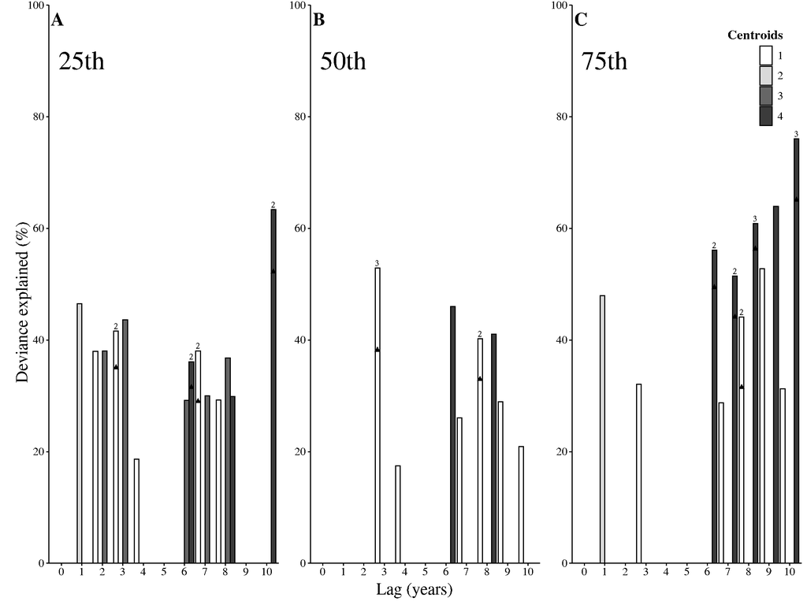

```r
# --- Loading results for DFA states and DTW centroids
load(paste0(out_dir_files, '/GLMs_DTW_results.RData'))
load(paste0(out_dir_files, '/GLMs_DFA_results.RData'))
# Centroids
c1 <- tables_states_glm(glm_dtw_results[['c1']], '1')
c2 <- tables_states_glm(glm_dtw_results[['c2']], '2')
c3 <- tables_states_glm(glm_dtw_results[['c3']], '3')
c4 <- tables_states_glm(glm_dtw_results[['c4']], '4')
# States
s1 <- tables_states_glm(glm_dfa_results[['s1']], '1')
s2 <- tables_states_glm(glm_dfa_results[['s2']], '2')
s3 <- tables_states_glm(glm_dfa_results[['s3']], '3')

# --- Getting list by percentile
percentiles <- c("th25", "th50", "th75")
# --- Function calls "states" and "centroids" lists (s1, s2, s3, and c1, c2, c3, c4)
cent_percentiles_list <- combine_by_percentiles(percentiles, prefix = "c", n_elements = 4)
stat_percentiles_list <- combine_by_percentiles(percentiles, prefix = "s", n_elements = 3)

# --- Getting each percentile as dataframe for "states" and "centroids"
# Centroids
cent_th25 <- cent_percentiles_list[["th25"]]
cent_th50 <- cent_percentiles_list[["th50"]]
cent_th75 <- cent_percentiles_list[["th75"]]
# States
stat_th25 <- stat_percentiles_list[["th25"]]
stat_th50 <- stat_percentiles_list[["th50"]]
stat_th75 <- stat_percentiles_list[["th75"]]

# --- Create each subplot element
# Centroids
c25 <- plot_de_lag_annotated(cent_th25, "25th", "A", fill_label = NULL)
c50 <- plot_de_lag_annotated(cent_th50, "50th", "B", fill_label = NULL)
c75 <- plot_de_lag_annotated(cent_th75, "75th", "C", show_legend = TRUE, fill_label = "Centroids", 0.8, 0.87)
# States
s25 <- plot_de_lag_annotated(stat_th25, "25th", "A", fill_label = NULL)
s50 <- plot_de_lag_annotated(stat_th50, "50th", "B", fill_label = NULL)
s75 <- plot_de_lag_annotated(stat_th75, "75th", "C", show_legend = TRUE, fill_label = "Trends", 0.92, 0.9)

# Merging plots into a single one and export it as PDF
# Centroids
file_path <- file.path(out_dir_fig, "Fig_S8")
# --- as PDF
pdf(paste0(file_path, ".pdf"), width = 12, height = 9, colormodel = "cmyk")
par(mfcol=c(1,1))
figure <- ggarrange(c25, c50, c75,
                    ncol = 3, nrow = 1, common.legend = F)
f_dtw <- annotate_figure(
  figure,
  bottom = textGrob(
    expression(paste("Lag (years)")),
    rot = 0, vjust = 0.3,
    gp = gpar(cex = 1.5, fontfamily = "Times" , fontsize = 12)
  ),
  left = textGrob(
    expression(paste("Deviance explained (%)")),
    rot = 90, vjust = 1.3,
    gp = gpar(cex = 1.5, fontfamily = "Times" , fontsize = 12)
  ))
print(f_dtw)
invisible(dev.off())
# --- as PNG
ragg::agg_png(paste0(file_path, ".png"), width = 12, height = 9, units = "in", res = 600)
print(f_dtw)
invisible(dev.off())
# HTML output
if (knitr::is_html_output()) {
  cat("\n\n")
  print(f_dtw)
  cat("\n\n**Figure S8.-** Average (triangles) and maximum (bars) deviance explained (%) by GLMs for the DTW-derived centroids 1-4 at different time lags (from 0 to 10 years). Numbers above the bars indicate the count of significant models for each specific lag. \n\n")
}
```

**Figure S8.-** Average (triangles) and maximum (bars) deviance explained (%) by GLMs for the DTW-derived centroids 1-4 at different time lags (from 0 to 10 years). Numbers above the bars indicate the count of significant models for each specific lag.

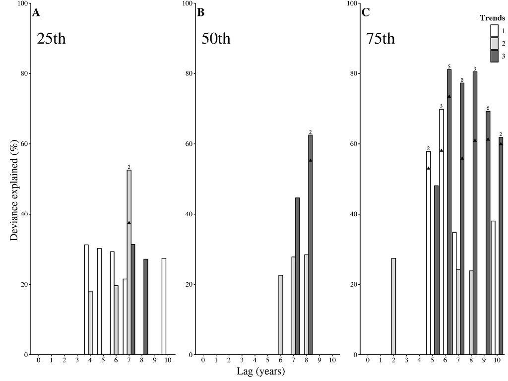

```r
# States
file_path <- file.path(out_dir_fig, "Fig_S9")
# --- as PDF
pdf(paste0(file_path, ".pdf"), width = 12, height = 9, colormodel = "cmyk")
par(mfcol=c(1,1))
figure <- ggarrange(s25, s50, s75,
                    ncol = 3, nrow = 1, common.legend = F)
f_dtw <- annotate_figure(
  figure,
  bottom = textGrob(
    expression(paste("Lag (years)")),
    rot = 0, vjust = 0.3,
    gp = gpar(cex = 1.5, fontfamily = "Times" , fontsize = 12)
  ),
  left = textGrob(
    expression(paste("Deviance explained (%)")),
    rot = 90, vjust = 1.3,
    gp = gpar(cex = 1.5, fontfamily = "Times" , fontsize = 12)
  ))
print(f_dtw)
invisible(dev.off())
# --- as PNG
ragg::agg_png(paste0(file_path, ".png"), width = 12, height = 9, units = "in", res = 600)
print(f_dtw)
invisible(dev.off())
# HTML output
if (knitr::is_html_output()) {
  cat("\n\n")
  print(f_dtw)
  cat("\n\n**Figure S9.-** Average (triangles) and maximum (bars) deviance explained (%) by GLMs for the DFA-derived common hidden trends at different time lags (from 0 to 10 years). Numbers above the bars indicate the count of significant models for each specific lag. \n\n\n\n
  To get the estimated parameters of the explanatory variables presented in Table 2 it is necessary to check the results saved in 'glm_dtw_results' and 'glm_dfa_results'.")
}
```

**Figure S9.-** Average (triangles) and maximum (bars) deviance explained (%) by GLMs for the DFA-derived common hidden trends at different time lags (from 0 to 10 years). Numbers above the bars indicate the count of significant models for each specific lag.

To get the estimated parameters of the explanatory variables presented in Table 2 it is necessary to check the results saved in ‘glm_dtw_results’ and ‘glm_dfa_results’.

## GLMs with highest Deviance Explained for DTW-centroids and DFA-states

```
===============  Centroid 1 ===============
```

```
Call:
glm(formula = "c1 ~ riv50 + kd50 + sss50 + riv50:kd50 + riv50:sss50",
    family = quasi(link = "identity", variance = "constant"),
    data = env_fish_lag_dtw[[4]], na.action = na.omit)

Coefficients:
              Estimate Std. Error t value Pr(>|t|)
(Intercept) -4.727e-01  1.448e-01  -3.265   0.0043 **
riv50       -2.945e-05  2.542e-05  -1.158   0.2618
kd50         6.774e-01  1.201e+01   0.056   0.9556
sss50       -2.981e+00  1.227e+00  -2.429   0.0259 *
riv50:kd50   8.960e-03  3.861e-03   2.321   0.0322 *
riv50:sss50  8.505e-04  3.418e-04   2.488   0.0229 *
---
Signif. codes:  0 '***' 0.001 '**' 0.01 '*' 0.05 '.' 0.1 ' ' 1

(Dispersion parameter for quasi family taken to be 0.2327936)

    Null deviance: 8.8972  on 23  degrees of freedom
Residual deviance: 4.1903  on 18  degrees of freedom
  (14 observations deleted due to missingness)
AIC: NA

Number of Fisher Scoring iterations: 2
```

```
# Check for Multicollinearity

Low Correlation

        Term  VIF   VIF 95% CI adj. VIF Tolerance Tolerance 95% CI
       riv50 3.22 [2.15, 5.28]     1.80      0.31     [0.19, 0.46]
        kd50 2.10 [1.50, 3.39]     1.45      0.48     [0.30, 0.67]
       sss50 2.08 [1.49, 3.36]     1.44      0.48     [0.30, 0.67]
  riv50:kd50 3.38 [2.25, 5.55]     1.84      0.30     [0.18, 0.45]
 riv50:sss50 2.61 [1.80, 4.25]     1.62      0.38     [0.24, 0.56]
```

```
    Shapiro-Wilk normality test

data:  model_dtw$residuals
W = 0.96499, p-value = 0.5466
```

```
         term DE_change_pct DE_contribution_relative
1  riv50:kd50         14.09                    24.61
2 riv50:sss50         16.20                    28.29
```

```
 =============== Centroid 2 ===============
```

```
Call:
glm(formula = "c2 ~ kd75 + sss75", family = quasi(link = "identity",
    variance = "constant"), data = env_fish_lag_dtw[[2]], na.action = na.omit)

Coefficients:
            Estimate Std. Error t value Pr(>|t|)
(Intercept)   0.2708     0.1292   2.095 0.047350 *
kd75         37.0127     8.5096   4.349 0.000236 ***
sss75         2.4383     1.0200   2.390 0.025406 *
---
Signif. codes:  0 '***' 0.001 '**' 0.01 '*' 0.05 '.' 0.1 ' ' 1

(Dispersion parameter for quasi family taken to be 0.3477156)

    Null deviance: 15.3682  on 25  degrees of freedom
Residual deviance:  7.9975  on 23  degrees of freedom
  (12 observations deleted due to missingness)
AIC: NA

Number of Fisher Scoring iterations: 2
```

```
# Check for Multicollinearity

Low Correlation

  Term  VIF    VIF 95% CI adj. VIF Tolerance Tolerance 95% CI
  kd75 1.05 [1.00, 68.20]     1.02      0.96     [0.01, 1.00]
 sss75 1.05 [1.00, 68.20]     1.02      0.96     [0.01, 1.00]
```

```
    Shapiro-Wilk normality test

data:  model_dtw$residuals
W = 0.97588, p-value = 0.7769
```

```
   term DE_change_pct DE_contribution_relative
1  kd75         42.80                    36.83
2 sss75         12.93                    11.13
```

```
 =============== Centroid 3 ===============
```

```
Call:
glm(formula = "c3 ~ riv25 + sss25 + riv25:sss25", family = quasi(link = "identity",
    variance = "constant"), data = env_fish_lag_dtw[[4]], na.action = na.omit)

Coefficients:
              Estimate Std. Error t value Pr(>|t|)
(Intercept)  5.622e-01  1.792e-01   3.137 0.004475 **
riv25       -1.024e-04  3.982e-05  -2.571 0.016770 *
sss25       -5.989e+00  1.428e+00  -4.194 0.000322 ***
riv25:sss25  8.318e-04  3.490e-04   2.383 0.025433 *
---
Signif. codes:  0 '***' 0.001 '**' 0.01 '*' 0.05 '.' 0.1 ' ' 1

(Dispersion parameter for quasi family taken to be 0.4391683)

    Null deviance: 18.685  on 27  degrees of freedom
Residual deviance: 10.540  on 24  degrees of freedom
  (10 observations deleted due to missingness)
AIC: NA

Number of Fisher Scoring iterations: 2
```

```
# Check for Multicollinearity

Low Correlation

        Term  VIF   VIF 95% CI adj. VIF Tolerance Tolerance 95% CI
       riv25 2.40 [1.64, 4.07]     1.55      0.42     [0.25, 0.61]
       sss25 1.65 [1.23, 2.81]     1.28      0.61     [0.36, 0.81]
 riv25:sss25 2.90 [1.92, 4.95]     1.70      0.34     [0.20, 0.52]
```

```
    Shapiro-Wilk normality test

data:  model_dtw$residuals
W = 0.95333, p-value = 0.2399
```

```
         term DE_change_pct DE_contribution_relative
1 riv25:sss25         13.35                    43.59
```

```
 =============== Centroid 4 ===============
```

```
Call:
glm(formula = "c4 ~ soi + riv75 + kd75", family = quasi(link = "identity",
    variance = "constant"), data = env_fish_lag_dtw[[11]], na.action = na.omit)

Coefficients:
              Estimate Std. Error t value Pr(>|t|)
(Intercept) -7.091e-01  9.163e-02  -7.738 3.21e-06 ***
soi          1.925e-01  8.022e-02   2.399  0.03214 *
riv75        7.132e-05  1.131e-05   6.305 2.72e-05 ***
kd75        -2.202e+01  7.066e+00  -3.116  0.00819 **
---
Signif. codes:  0 '***' 0.001 '**' 0.01 '*' 0.05 '.' 0.1 ' ' 1

(Dispersion parameter for quasi family taken to be 0.09849534)

    Null deviance: 5.3440  on 16  degrees of freedom
Residual deviance: 1.2804  on 13  degrees of freedom
  (21 observations deleted due to missingness)
AIC: NA

Number of Fisher Scoring iterations: 2
```

```
# Check for Multicollinearity

Low Correlation

  Term  VIF   VIF 95% CI adj. VIF Tolerance Tolerance 95% CI
   soi 1.44 [1.12, 2.65]     1.20      0.70     [0.38, 0.90]
 riv75 1.62 [1.20, 2.90]     1.27      0.62     [0.34, 0.83]
  kd75 1.21 [1.03, 2.70]     1.10      0.82     [0.37, 0.97]
```

```
    Shapiro-Wilk normality test

data:  model_dtw$residuals
W = 0.96099, p-value = 0.6502
```

```
   term DE_change_pct DE_contribution_relative
1   soi         10.61                     7.93
2 riv75         73.28                    54.74
3  kd75         17.90                    13.37
```

```
 =============== Common hidden trend 1 ===============
```

```
Call:
glm(formula = "s1 ~ riv75 + kd75 + wmi75", family = quasi(link = "identity",
    variance = "constant"), data = env_fish_lag_dfa[[7]], na.action = na.omit)

Coefficients:
              Estimate Std. Error t value Pr(>|t|)
(Intercept) -7.543e-01  2.851e-01  -2.645   0.0170 *
riv75        8.164e-05  3.633e-05   2.247   0.0382 *
kd75        -1.324e+02  2.153e+01  -6.149 1.07e-05 ***
wmi75       -9.674e-02  3.962e-02  -2.441   0.0259 *
---
Signif. codes:  0 '***' 0.001 '**' 0.01 '*' 0.05 '.' 0.1 ' ' 1

(Dispersion parameter for quasi family taken to be 1.556002)

    Null deviance: 87.656  on 20  degrees of freedom
Residual deviance: 26.452  on 17  degrees of freedom
  (17 observations deleted due to missingness)
AIC: NA

Number of Fisher Scoring iterations: 2
```

```
[1] 69.82
```

```
# Check for Multicollinearity

Low Correlation

  Term  VIF   VIF 95% CI adj. VIF Tolerance Tolerance 95% CI
 riv75 1.36 [1.08, 2.55]     1.17      0.73     [0.39, 0.92]
  kd75 1.35 [1.08, 2.54]     1.16      0.74     [0.39, 0.92]
 wmi75 1.17 [1.02, 2.87]     1.08      0.85     [0.35, 0.98]
```

```
    Shapiro-Wilk normality test

data:  model_dfa$residuals
W = 0.97263, p-value = 0.7903
```

```
   term DE_change_pct DE_contribution_relative
1 riv75          8.97                     7.23
2  kd75         67.12                    54.07
3 wmi75         10.58                     8.52
```

```
 =============== Common hidden trend 2 ===============
```

```
Call:
glm(formula = "s2 ~ sam + sst25 + kd25", family = quasi(link = "identity",
    variance = "constant"), data = env_fish_lag_dfa[[8]], na.action = na.omit)

Coefficients:
            Estimate Std. Error t value Pr(>|t|)
(Intercept)  -1.8516     0.2855  -6.484 7.53e-06 ***
sam           0.3358     0.1423   2.360   0.0313 *
sst25        -0.9164     0.3866  -2.370   0.0307 *
kd25         48.6226    20.4772   2.374   0.0304 *
---
Signif. codes:  0 '***' 0.001 '**' 0.01 '*' 0.05 '.' 0.1 ' ' 1

(Dispersion parameter for quasi family taken to be 0.845074)

    Null deviance: 28.479  on 19  degrees of freedom
Residual deviance: 13.521  on 16  degrees of freedom
  (18 observations deleted due to missingness)
AIC: NA

Number of Fisher Scoring iterations: 2
```

```
[1] 52.52
```

```
# Check for Multicollinearity

Low Correlation

  Term  VIF    VIF 95% CI adj. VIF Tolerance Tolerance 95% CI
   sam 1.09 [1.00,  5.46]     1.05      0.91     [0.18, 1.00]
 sst25 1.05 [1.00, 76.98]     1.02      0.96     [0.01, 1.00]
  kd25 1.11 [1.00,  4.38]     1.05      0.90     [0.23, 1.00]
```

```
    Shapiro-Wilk normality test

data:  model_dfa$residuals
W = 0.97976, p-value = 0.931
```

```
   term DE_change_pct DE_contribution_relative
1   sam         16.53                    17.39
2 sst25         16.67                    17.53
3  kd25         16.73                    17.60
```

```
 =============== Common hidden trend 3 ===============
```

```
Call:
glm(formula = s3 ~ soi + riv75 + kd75 + wmi75, family = quasi(link = "identity",
    variance = "constant"), data = env_fish_lag_dfa[[7]], na.action = na.omit)

Coefficients:
              Estimate Std. Error t value Pr(>|t|)
(Intercept) -1.334e+00  3.283e-01  -4.064 0.000902 ***
soi          8.219e-01  3.234e-01   2.541 0.021783 *
riv75        2.427e-04  4.684e-05   5.181 9.10e-05 ***
kd75        -1.694e+02  2.331e+01  -7.267 1.88e-06 ***
wmi75       -1.322e-01  4.293e-02  -3.080 0.007181 **
---
Signif. codes:  0 '***' 0.001 '**' 0.01 '*' 0.05 '.' 0.1 ' ' 1

(Dispersion parameter for quasi family taken to be 1.823238)

    Null deviance: 154.447  on 20  degrees of freedom
Residual deviance:  29.172  on 16  degrees of freedom
  (17 observations deleted due to missingness)
AIC: NA

Number of Fisher Scoring iterations: 2
```

```
[1] 81.11
```

```
# Check for Multicollinearity

Low Correlation

  Term  VIF   VIF 95% CI adj. VIF Tolerance Tolerance 95% CI
   soi 1.57 [1.20, 2.67]     1.25      0.64     [0.37, 0.84]
 riv75 1.93 [1.39, 3.24]     1.39      0.52     [0.31, 0.72]
  kd75 1.36 [1.09, 2.41]     1.16      0.74     [0.42, 0.92]
 wmi75 1.17 [1.02, 2.60]     1.08      0.85     [0.38, 0.98]
```

```
    Shapiro-Wilk normality test

data:  model_dfa$residuals
W = 0.95803, p-value = 0.4774
```

```
   term DE_change_pct DE_contribution_relative
1   soi          7.62                     5.48
2 riv75         31.69                    22.78
3  kd75         62.34                    44.81
4 wmi75         11.20                     8.05
```

## QQ-plots used to evaluate residuals normality for GLMs

```r
# Final QQ-plot for GLMs
qq_final_plot_glm <- (
  qqplot_glm_c1 + qqplot_glm_c2 + qqplot_glm_c3 + qqplot_glm_c4 +
    qqplot_glm_s1 + qqplot_glm_s2 + qqplot_glm_s3
  ) +
  plot_layout(design = "
              1234
              567#")
# Save figure
file_path <- file.path(out_dir_fig, "Fig_S10")
# --- as PDF
pdf(paste0(file_path, ".pdf"), width = 12, height = 9, colormodel = "cmyk")
par(mfcol=c(1,1))
qq_final_plot_glm
grid::grid.draw(qq_final_plot_glm)
invisible(dev.off())
# --- as PNG
ragg::agg_png(paste0(file_path, ".png"), width = 12, height = 9, units = "in", res = 600)
grid::grid.draw(qq_final_plot_glm)
invisible(dev.off())
# HTML output
file_png <- paste0(file_path,".png")
if (knitr::is_html_output() && file.exists(file_png)) {
  knitr::include_graphics(file_png)
}
```

[figure not shown]

**Figure S10.-** Quantile-quantile (QQ) plots of residuals for the selected GLM models. Panels (A – D) correspond to the fitted models for Centroid 1 to 4 derived from the Dynamic Time Warping (DTW) analysis, and panels E – G for Common hidden trends 1 to 3 derived from the Dynamic Factor (DFA) analysis, respectively.

*While minor deviations in the extreme quantiles may be observed in panels D and G, both figures display strong fits along the central quantiles, suggesting that the errors are approximately normally distributed. Such deviations are expected in high-variability environmental and fisheries datasets and do not indicate systematic bias. The consistent results from the Shapiro–Wilk test and the well-behaved central quantiles in the QQ-plots support the validity of the normality assumption for model errors.*

# **GAMs analyses for i) DTW-centroids and ii) DFA-states**

## Getting all possible formulas

```r
##| results: asis
th <- c('25','50','75') # percentiles
response <- "y"  # generic name for response variable
gams_formulas_by_ix <- list()
for(k in 1:length(th)){
  # List of variables and index selection
  vq <- c(th[k], response)
  idx_var <- to_vec(
    for(i in 1:length(vq)) str_which(names_col, vq[i], negate = FALSE)
  )
  names_var <- c('soi','sam','enso', names_col[idx_var])

  #  Combinations of climate indices
  ci <- c('soi','sam','enso')
  cixs <- to_list(
    for(i in 1:length(ci)) c(combn(ci, i, simplify = FALSE))
  )

  cixss <- list()
  cixss[[1]] <- cixs[[2]]   # pairs
  cixss[[1]][[4]] <- unlist(cixs[[3]]) # all

  for(ix in 1:length(cixss[[1]])){
    cith <- paste(paste(cixss[[1]][[ix]], collapse = '|'), sep = '|')
    names_var_ix <- names_var[-grep(pattern = cith, names_var)]

    #  Remove percentile tag
    for(tag in th[k]) names_var_ix <- gsub(tag,'', names_var_ix)

    # Covariates and response
    xnames <- names_var_ix
    ynames <- response

    # Formulas with interactions
    inter <- c("riv", "kd", "sss")
    gams_f <- comb_gami(xnames, ynames, 4, inter)

    if(ix < length(cixss[[1]])){
      gams_f <- gams_f[grep(pattern = paste(cixss[[1]][[4]], collapse = '|'), gams_f)]
    }
    gams_formulas_by_ix[[ix]] <- gams_f
  }
}
# Combine all formulas into a single object
gams_formulas <- do.call(c, gams_formulas_by_ix)
# Transform to character
# gams_formulas_chr <- sapply(
#   gams_formulas, function(f) paste(deparse(f), collapse = " ")
#   )
clean_format <- function(x) paste(format(x), collapse = "")
head_f <- sapply(head(gams_formulas, 3), clean_format)
tail_f <- sapply(tail(gams_formulas, 3), clean_format)
cat(paste(head_f, collapse = "\n\n"),
    "\n\n... and so on until... \n\n",
    paste(tail_f, collapse = "\n\n"),
    sep = ""
    )
```

y ~ s(enso, k = 4, bs = “cr”)

y ~ s(enso, k = 4, bs = “cr”) + s(riv, k = 4, bs = “cr”)

y ~ s(enso, k = 4, bs = “cr”) + s(sst, k = 4, bs = “cr”)

… and so on until…

y ~ s(riv, k = 4, bs = “cr”) + s(kd, k = 4, bs = “cr”) + s(sss, k = 4, bs = “cr”) + s(wmi, k = 4, bs = “cr”) + ti(riv, kd, k = 4, bs = “cr”) + ti(riv, sss, k = 4, bs = “cr”)

y ~ s(sst, k = 4, bs = “cr”) + s(kd, k = 4, bs = “cr”) + s(sss, k = 4, bs = “cr”) + s(wmi, k = 4, bs = “cr”)

y ~ s(riv, k = 4, bs = “cr”) + s(sst, k = 4, bs = “cr”) + s(kd, k = 4, bs = “cr”) + s(sss, k = 4, bs = “cr”) + s(wmi, k = 4, bs = “cr”) + ti(riv, kd, k = 4, bs = “cr”) + ti(riv, sss, k = 4, bs = “cr”)

## Run GAMs for DTW-centroids

```r
set.seed(23)
suppressWarnings({
gam_dtw_results <- run_gams_nested(
  nvariables = 4,
  env_fish_lag = env_fish_lag_dtw,
  lag = lag, # lags
  th = th, # percentiles
  gams_formulas = gams_formulas, # list
  fmly = list(quasi(link = "identity", variance = "constant")), # family
  add_th_suffix = add_th_suffix, # function
  try_gam_stepwise = try_gam_stepwise, # function
  p_threshold = 0.05, # ADDED
  concurvity_threshold = 0.3, # ADDED
  method = "REML")
})
```

## Save summaries of significant models

```r
outfile <- paste0(out_dir_files, '/SupplementaryMaterial_S14_GAMs_DTW.txt')
sink(outfile, append = FALSE)
print_gam_nested_results(gam_dtw_results)
sink()
closeAllConnections()
```

## Run GAMs for DFA-states

```r
set.seed(23)
suppressWarnings({
gam_dfa_results <- run_gams_nested(
  nvariables = 3,
  env_fish_lag = env_fish_lag_dfa,
  lag = lag, # lags
  th = th, # percentiles
  gams_formulas = gams_formulas, # list
  fmly = list(quasi(link = "identity", variance = "constant")), # family
  add_th_suffix = add_th_suffix, # function
  try_gam_stepwise = try_gam_stepwise, # function
  p_threshold = 0.05, # ADDED
  concurvity_threshold = 0.3, # ADDED
  method = "REML")
})
```

## Save summaries of significant models

```r
outfile <- paste0(out_dir_files, '/SupplementaryMaterial_S15_GAMs_DFA.txt')
sink(outfile, append = FALSE)
print_gam_nested_results(gam_dfa_results)
sink()
closeAllConnections()
```

## Save the outputs as R dataset objects

```r
# For DTW centroids as response variable
save(
  gam_dtw_results,
  file = file.path(out_dir_files,'GAMs_DTW_results.RData')
  )
# For DFA states as response variable
save(
  gam_dfa_results,
  file = file.path(out_dir_files, 'GAMs_DFA_results.RData')
  )
```

# **Load GAMs results, create subplot elements and plot lags and DE for centroids and common hidden trends**

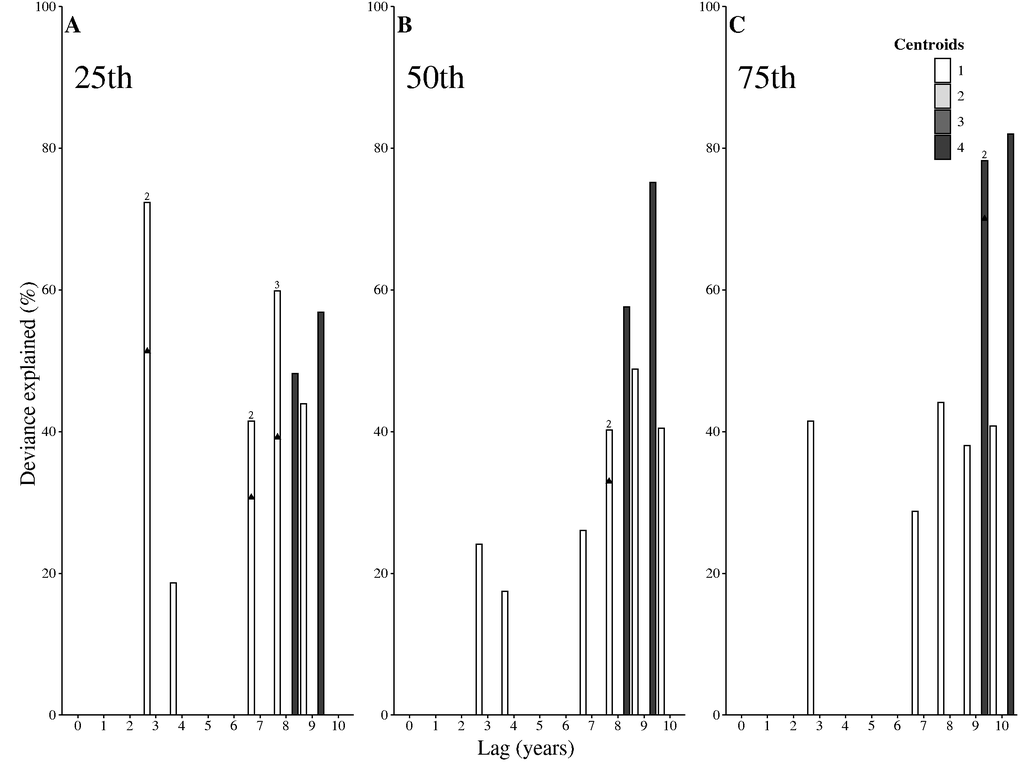

```r
# --- Loading results for DFA states and DTW centroids
load(paste0(out_dir_files, '/GAMs_DTW_results.RData'))
load(paste0(out_dir_files, '/GAMs_DFA_results.RData'))
# Centroids
c1 <- tables_states_gam(gam_dtw_results[['c1']], '1')
c2 <- tables_states_gam(gam_dtw_results[['c2']], '2')
c3 <- tables_states_gam(gam_dtw_results[['c3']], '3')
c4 <- tables_states_gam(gam_dtw_results[['c4']], '4')
# States
s1 <- tables_states_gam(gam_dfa_results[['s1']], '1')
s2 <- tables_states_gam(gam_dfa_results[['s2']], '2')
s3 <- tables_states_gam(gam_dfa_results[['s3']], '3')
# --- Getting list by percentile
percentiles <- c("th25", "th50", "th75")
# --- Function calls "states" and "centroids" lists (s1, s2, s3, and c1, c2, c3, c4)
stat_percentiles_list <- combine_by_percentiles(percentiles, prefix = "s", n_elements = 3)
cent_percentiles_list <- combine_by_percentiles(percentiles, prefix = "c", n_elements = 4)

# --- Getting each percentile as dataframe for "states" and "centroids"
# Centroids
cent_th25 <- cent_percentiles_list[["th25"]]
cent_th50 <- cent_percentiles_list[["th50"]]
cent_th75 <- cent_percentiles_list[["th75"]]
# States
stat_th25 <- stat_percentiles_list[["th25"]]
stat_th50 <- stat_percentiles_list[["th50"]]
stat_th75 <- stat_percentiles_list[["th75"]]

# --- Create each subplot element
# Centroids
c25 <- plot_de_lag_annotated(cent_th25, "25th", "A", fill_label = NULL)
c50 <- plot_de_lag_annotated(cent_th50, "50th", "B", fill_label = NULL)
c75 <- plot_de_lag_annotated(cent_th75, "75th", "C", show_legend = TRUE, fill_label = "Centroids", 0.7, 0.87)
# States
s25 <- plot_de_lag_annotated(stat_th25, "25th", "A", fill_label = NULL)
s50 <- plot_de_lag_annotated(stat_th50, "50th", "B", fill_label = NULL)
s75 <- plot_de_lag_annotated(stat_th75, "75th", "C", show_legend = TRUE, fill_label = "Trends", 0.92, 0.9)

# Merging plots into a single one and export it as PDF
# Centroids
file_path <- file.path(out_dir_fig, "Fig_S11")
# --- as PDF
pdf(paste0(file_path, ".pdf"), width = 12, height = 9, colormodel = "cmyk")
par(mfcol=c(1,1))
figure <- ggarrange(c25, c50, c75,
                    ncol = 3, nrow = 1, common.legend = F)
f_dtw <- annotate_figure(
  figure,
  bottom = textGrob(
    expression(paste("Lag (years)")),
    rot = 0, vjust = 0.3,
    gp = gpar(cex = 1.5, fontfamily = "Times" , fontsize = 12)
  ),
  left = textGrob(
    expression(paste("Deviance explained (%)")),
    rot = 90, vjust = 1.3,
    gp = gpar(cex = 1.5, fontfamily = "Times" , fontsize = 12)
  ))
print(f_dtw)
invisible(dev.off())
# --- as PNG
ragg::agg_png(paste0(file_path, ".png"), width = 12, height = 9, units = "in", res = 600)
print(f_dtw)
invisible(dev.off())
# HTML output
if (knitr::is_html_output()) {
  cat("\n\n")
  print(f_dtw)
  cat("\n\n**Figure S11.-** Average (triangles) and maximum (bars) deviance explained (%) by GAMs for the DTW-derived centroids 1-4 at different time lags (from 0 to 10 years). Numbers above the bars indicate the count of significant models for each specific lag. \n\n")
}
```

**Figure S11.-** Average (triangles) and maximum (bars) deviance explained (%) by GAMs for the DTW-derived centroids 1-4 at different time lags (from 0 to 10 years). Numbers above the bars indicate the count of significant models for each specific lag.

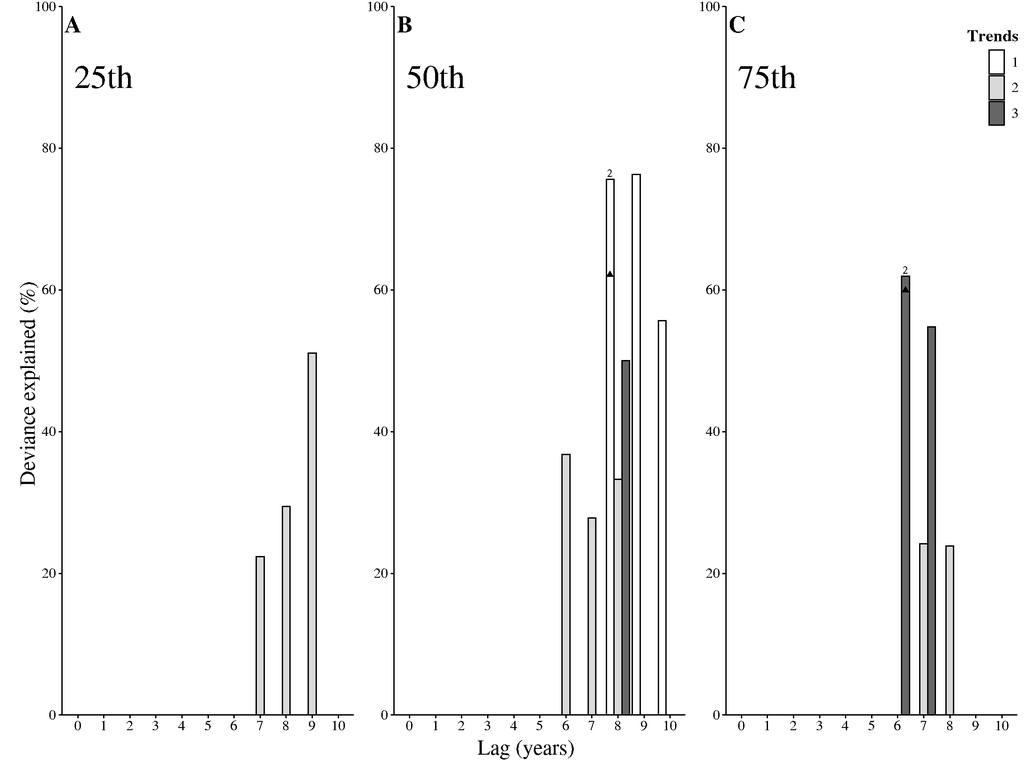

```r
# States
file_path <- file.path(out_dir_fig, "Fig_S12")
# --- as PDF
pdf(paste0(file_path, ".pdf"), width = 12, height = 9, colormodel = "cmyk")
par(mfcol=c(1,1))
figure <- ggarrange(s25, s50, s75,
                    ncol = 3, nrow = 1, common.legend = F)
f_dtw <- annotate_figure(
  figure,
  bottom = textGrob(
    expression(paste("Lag (years)")),
    rot = 0, vjust = 0.3,
    gp = gpar(cex = 1.5, fontfamily = "Times" , fontsize = 12)
  ),
  left = textGrob(
    expression(paste("Deviance explained (%)")),
    rot = 90, vjust = 1.3,
    gp = gpar(cex = 1.5, fontfamily = "Times" , fontsize = 12)
  ))
print(f_dtw)
invisible(dev.off())
# --- as PNG
ragg::agg_png(paste0(file_path, ".png"), width = 12, height = 9, units = "in", res = 600)
print(f_dtw)
invisible(dev.off())
# HTML output
if (knitr::is_html_output()) {
  cat("\n\n")
  print(f_dtw)
  cat("\n\n**Figure S12.-** Average (triangles) and maximum (bars) deviance explained (%) by GAMs for the DFA-derived common hidden trends at different time lags (from 0 to 10 years). Numbers above the bars indicate the count of significant models for each specific lag.\n\n\n\n
  To get the estimated parameters of the explanatory variables presented in Table 3 it is necessary to check the results saved in 'gam_dtw_results' and 'gam_dfa_results.'")
}
```

**Figure S12.-** Average (triangles) and maximum (bars) deviance explained (%) by GAMs for the DFA-derived common hidden trends at different time lags (from 0 to 10 years). Numbers above the bars indicate the count of significant models for each specific lag.

To get the estimated parameters of the explanatory variables presented in Table 3 it is necessary to check the results saved in ‘gam_dtw_results’ and ‘gam_dfa_results.’

## GAMs with highest Deviance Explained for DTW-centroids and DFA-states

```r
set.seed(123)
# Checking model residuals for DTW with highest DE, and plotting
# --- Centroid 1
cat("=============== Centroid 1 ===============")
model_dtw <- gam(
  (c1 ~ s(sst25, k = 4, bs = "cr") + s(kd25, k = 4, bs = "cr")),
  family = quasi(link="identity", variance="constant"),
  data = env_fish_lag_dtw[[4]], na.action = na.omit, method = "REML"
  )
summary(model_dtw)
de_dtw <- round((1 - model_dtw[["deviance"]] / model_dtw[["null.deviance"]]) * 100, digits = 2)
concurvity(model_dtw)
shapiro.test(model_dtw$residuals)
# QQ-plot of residuals
qq_obj <- as.data.frame(gratia::qq_plot(model_dtw)[1][["data"]])
qqplot_gam_c1 <- plot_qq(qq_obj, "A")
# Contribution of each variable
var_contrib_from_full_gam(model_dtw)
# Figure
vrs <- names(model_dtw[["var.summary"]]) #
col_line <- c("#FF6347", "#E69F00") # sst, kd
plot_list <- list() # We create the list to store the plots
tag_positions <- list(c(0.35, 0.975), c(0.21, 0.975))
for(i in seq_along(vrs)) { # iterate from 1 to the number of variables
  # Get data for this iteration
  var_selected <- vrs[i]
  color_selected <- col_line[i]
  # Call the plotting function
  p <- plot_gam_effect(
    model_dtw, var_selected, color_selected,
    y_label = if (i == 1) "Predicted Value\n(DBA Centroid 1)" else NULL
  )
  # Add the tag (LETTERS)
  plot_list[[var_selected]] <- p + labs(tag = LETTERS[i]) +
    theme(
      plot.tag.position = tag_positions[[i]],
      plot.tag = element_text(
        face = "bold", size = 20)
      )
}
# Saving figure elements
plot_GAM_c1 <- plot_list
save(plot_GAM_c1,
  file = paste0("outputs/files/",'Fig_8_AB_c1_GAM.RData')
  )
# --- Centroid 4
cat("\n\n =============== Centroid 4 ===============")
model_dtw <- gam(
  (c4 ~ s(sam, k = 4, bs = "cr") + s(kd75, k = 4, bs = "cr")),
  family = quasi(link="identity", variance="constant"),
  data = env_fish_lag_dtw[[11]], na.action = na.omit, method = "REML"
  )
summary(model_dtw)
de_dtw <- round((1 - model_dtw[["deviance"]] / model_dtw[["null.deviance"]]) * 100, digits = 2)
concurvity(model_dtw)
shapiro.test(model_dtw$residuals)
# QQ-plot of residuals
qq_obj <- as.data.frame(gratia::qq_plot(model_dtw)[1][["data"]])
qqplot_gam_c4 <- plot_qq(qq_obj, "B")
# Contribution of each variable
var_contrib_from_full_gam(model_dtw)
# Figure
vrs <- names(model_dtw[["var.summary"]]) #
col_line <- c("#FFB6C1", "#E69F00") # sam, kd
plot_list <- list() # We create the list to store the plots
tag_positions <- list(c(0.35, 0.975), c(0.21, 0.975))
for(i in seq_along(vrs)) { # iterate from 1 to the number of variables
  # Get data for this iteration
  var_selected <- vrs[i]
  color_selected <- col_line[i]
  # Call the plotting function
  p <- plot_gam_effect(
    model_dtw, var_selected, color_selected,
    y_label = if (i == 1) "Predicted Value\n(DBA Centroid 4)" else NULL
  )
  # Add the tag (LETTERS)
  plot_list[[var_selected]] <- p + labs(tag = LETTERS[i+7]) +
    theme(
      plot.tag.position = tag_positions[[i]],
      plot.tag = element_text(
        face = "bold", size = 20)
      )
}
# Saving figure elements
plot_GAM_c4 <- plot_list
save(plot_GAM_c4,
  file = paste0("outputs/files/",'Fig_8_HI_c4_GAM.RData')
  )

# Checking model residuals for DFA with highest DE, and plotting
# --- State 1
cat("\n\n =============== Common hidden trend 1 ===============")
model_dfa <- gam(
  (s1 ~ s(soi, k = 4, bs = "cr") + s(kd50, k = 4, bs = "cr")),
  family = quasi(link="identity", variance="constant"),
  data = env_fish_lag_dfa[[10]], na.action = na.omit, method = "REML"
  )
summary(model_dfa)
de_dfa <- round((1 - model_dfa[["deviance"]] / model_dfa[["null.deviance"]]) * 100, digits = 2)
concurvity(model_dfa)
shapiro.test(model_dfa$residuals)
# QQ-plot of residuals
qq_obj <- as.data.frame(gratia::qq_plot(model_dfa)[1][["data"]])
qqplot_gam_s1 <- plot_qq(qq_obj, "C")
# Contribution of each variable
var_contrib_from_full_gam(model_dfa)
# Figure
vrs <- names(model_dfa[["var.summary"]]) #
col_line <- c("#492050", "#E69F00") # soi, kd
plot_list <- list() # We create the list to store the plots
tag_positions <- list(c(0.35, 0.975), c(0.21, 0.975))
for(i in seq_along(vrs)) { # iterate from 1 to the number of variables
  # Get data for this iteration
  var_selected <- vrs[i]
  color_selected <- col_line[i]
  # Call the plotting function
  p <- plot_gam_effect(
    model_dfa, var_selected, color_selected,
    y_label = if (i == 1) "Predicted Value\n(DFA Common trend 1)" else NULL
  )
  # Add the tag (LETTERS)
  plot_list[[var_selected]] <- p + labs(tag = LETTERS[i]) +
    theme(
      plot.tag.position = tag_positions[[i]],
      plot.tag = element_text(
        face = "bold", size = 20)
      )
}
# Saving figure elements
plot_GAM_s1 <- plot_list
save(plot_GAM_s1,
  file = paste0("outputs/files/",'Fig_9_AB_s1_GAM.RData')
  )
# --- State 2
cat("\n\n =============== Common hidden trend 2 ===============")
model_dfa <- gam(
  (s2 ~ s(sss25, k = 4, bs = "cr") + s(sst25, k = 4, bs = "cr")),
  family = quasi(link="identity", variance="constant"),
  data = env_fish_lag_dfa[[10]], na.action = na.omit, method = "REML"
  )
summary(model_dfa)
de_dfa <- round((1 - model_dfa[["deviance"]] / model_dfa[["null.deviance"]]) * 100, digits = 2)
concurvity(model_dfa)
shapiro.test(model_dfa$residuals)
# QQ-plot of residuals
qq_obj <- as.data.frame(gratia::qq_plot(model_dfa)[1][["data"]])
qqplot_gam_s2 <- plot_qq(qq_obj, "D")
# Contribution of each variable
var_contrib_from_full_gam(model_dfa)
# --- State 3
cat("\n\n =============== Common hidden trend 3 ===============")
model_dfa <- gam(
  (s3 ~ s(kd75, k = 4, bs = "cr") + s(sss75, k = 4, bs = "cr")),
  family = quasi(link="identity", variance="constant"),
  data = env_fish_lag_dfa[[7]], na.action = na.omit, method = "REML"
  )
summary(model_dfa)
de_dfa <- round((1 - model_dfa[["deviance"]] / model_dfa[["null.deviance"]]) * 100, digits = 2)
concurvity(model_dfa)
shapiro.test(model_dfa$residuals)
# QQ-plot of residuals
qq_obj <- as.data.frame(gratia::qq_plot(model_dfa)[1][["data"]])
qqplot_gam_s3 <- plot_qq(qq_obj, "E")
# Contribution of each variable
var_contrib_from_full_gam(model_dfa)
```

```
=============== Centroid 1 ===============
Family: quasi
Link function: identity

Formula:
c1 ~ s(sst25, k = 4, bs = "cr") + s(kd25, k = 4, bs = "cr")

Parametric coefficients:
            Estimate Std. Error t value Pr(>|t|)
(Intercept) -0.31264    0.07435  -4.205 0.000502 ***
---
Signif. codes:  0 '***' 0.001 '**' 0.01 '*' 0.05 '.' 0.1 ' ' 1

Approximate significance of smooth terms:
           edf Ref.df     F p-value
s(sst25) 2.637  2.906 9.527 0.00134 **
s(kd25)  1.815  2.196 9.056 0.00159 **
---
Signif. codes:  0 '***' 0.001 '**' 0.01 '*' 0.05 '.' 0.1 ' ' 1

R-sq.(adj) =  0.657   Deviance explained = 72.3%
-REML = -8.4281  Scale est. = 0.13267   n = 24
                 para   s(sst25)    s(kd25)
worst    9.860761e-32 0.17452851 0.17452851
observed 9.860761e-32 0.02516632 0.13768979
estimate 9.860761e-32 0.14165991 0.07635622

    Shapiro-Wilk normality test

data:  model_dtw$residuals
W = 0.98082, p-value = 0.9104

      term     stat DE_contribution_relative
1 s(sst25) 9.526937                    37.09
2  s(kd25) 9.055837                    35.25


 =============== Centroid 4 ===============
Family: quasi
Link function: identity
```

[output cut: 128 more lines]

```
R-sq.(adj) =  0.547   Deviance explained = 61.9%
-REML = 21.092  Scale est. = 3.4985    n = 21
                 para   s(kd75)  s(sss75)
worst    3.451266e-31 0.2782925 0.2782925
observed 3.451266e-31 0.1284567 0.2591717
estimate 3.451266e-31 0.1674415 0.1412240

    Shapiro-Wilk normality test

data:  model_dfa$residuals
W = 0.97311, p-value = 0.8004

      term      stat DE_contribution_relative
1  s(kd75) 13.323990                    43.08
2 s(sss75)  5.833722                    18.86
```

## QQ-plots used to evaluate residuals normality for GAMs

```r
# Final QQ-plot for GAMs
qq_final_plot_gam <- (
  qqplot_gam_c1 + qqplot_gam_c4 + qqplot_gam_s1 + qqplot_gam_s2 + qqplot_gam_s3
  ) +
  plot_layout(design = "
              12#
              345")
# Save figure
file_path <- file.path(out_dir_fig, "Fig_S13")
# --- as PDF
pdf(paste0(file_path, ".pdf"), width = 12, height = 9, colormodel = "cmyk")
par(mfcol=c(1,1))
qq_final_plot_gam
grid::grid.draw(qq_final_plot_gam)
invisible(dev.off())
# --- as PNG
ragg::agg_png(paste0(file_path, ".png"), width = 12, height = 9, units = "in", res = 600)
grid::grid.draw(qq_final_plot_gam)
invisible(dev.off())
# HTML output
file_png <- paste0(file_path,".png")
if (knitr::is_html_output() && file.exists(file_png)) {
  knitr::include_graphics(file_png)
}
```

[figure not shown]

**Figure S13.-** Quantile-quantile (QQ) plots of residuals for the selected GAM models. Panels (A – B) correspond to the fitted models for Centroid 1 and 4 derived from the Dynamic Time Warping (DTW) analysis, and panels C – E for Common hidden trends 1 to 3 derived from the Dynamic Factor (DFA) analysis, respectively.

*While minor deviations in the extreme quantiles may be observed in panels B and C, both figures display strong fits along the central quantiles, suggesting that the errors are approximately normally distributed. Such deviations are expected in high-variability environmental and fisheries datasets and do not indicate systematic bias. The consistent results from the Shapiro–Wilk test and the well-behaved central quantiles in the QQ-plots support the validity of the normality assumption for model errors.*

# **Response plots of explanatory variables retained in the best-fitting GLM and GAM models for both centroids (Figure 8) and common hidden trends (Figure 9)**

```r
#  CENTROIDS ----
#path_plots <- paste0("out_dir_fig")
load(paste0(out_dir_files, '/Fig_8_AB_c1_GAM.RData'))
load(paste0(out_dir_files, '/Fig_8_CD_c2_GLM.RData'))
load(paste0(out_dir_files, '/Fig_8_EFG_c3_GLM.RData'))
load(paste0(out_dir_files, '/Fig_8_HI_c4_GAM.RData'))
nc = 4 # number of columns
row1 <- arrangeGrob(grobs = plot_GAM_c1, nrow = 1, ncol = nc)
row2 <- arrangeGrob(grobs = plot_GLM_c2, nrow = 1, ncol = nc)
row3 <- arrangeGrob(grobs = plot_GLM_c3[c(1,2,4)], nrow = 1, ncol = nc)
row4 <- arrangeGrob(grobs = plot_GAM_c4, nrow = 1, ncol = nc)
# Save figure
file_path <- file.path(out_dir_fig, "Fig_8")
# --- as PDF
pdf(paste0(file_path, ".pdf"), width = 12, height = 9, colormodel = "cmyk")
par(mfcol=c(1,1))
final_dtw <- grid.arrange(grobs = list(row1, row2, row3, row4), nrow = 4,
                          width = c(1, 1, 1))
grid::grid.draw(final_dtw)
invisible(dev.off())
# --- as PNG
ragg::agg_png(paste0(file_path, ".png"), width = 12, height = 9, units = "in", res = 600)
grid::grid.draw(final_dtw)
invisible(dev.off())
# HTML output
file_png <- paste0(file_path,".png")
if (knitr::is_html_output() && file.exists(file_png)) {
  knitr::include_graphics(file_png)
}
```

[figure not shown]

**Figure 8.-** Response plots for the best-fitting GLMs and GAMs obtained for the DTW-derived centroids 1–4. Each row corresponds to a centroid, and each panel shows the partial effect of the anomaly of one explanatory variable (or interaction) on its predicted values, based on the selected model for that centroid (see details about lags and percentiles in Tables 2 and 3). Solid lines represent the estimated mean effect, and shaded areas denote the 95% confidence intervals. Rug marks along the x-axis indicate the distribution of observed covariate values. Abbreviations of environmental explanatory variables are defined in Table 1

```r
#  TRENDS ----
load(paste0(out_dir_files, '/Fig_9_AB_s1_GAM.RData'))
load(paste0(out_dir_files, '/Fig_9_CDE_s2_GLM.RData'))
load(paste0(out_dir_files, '/Fig_9_FGHI_s3_GLM.RData'))
row1 <- arrangeGrob(grobs = plot_GAM_s1, nrow = 1, ncol = nc)
row2 <- arrangeGrob(grobs = plot_GLM_s2, nrow = 1, ncol = nc)
row3 <- arrangeGrob(grobs = plot_GLM_s3, nrow = 1, ncol = nc)
# Save figure
file_path <- file.path(out_dir_fig, "Fig_9")
# --- as PDF
pdf(paste0(file_path, ".pdf"), width = 12, height = 9, colormodel = "cmyk")
par(mfcol=c(1,1))
final_dfa <- grid.arrange(grobs = list(row1, row2, row3), nrow = 4,
                          )
grid::grid.draw(final_dfa)
invisible(dev.off())
# --- as PNG
ragg::agg_png(paste0(file_path, ".png"), width = 12, height = 9, units = "in", res = 600)
grid::grid.draw(grid.arrange(grobs = list(row1, row2, row3), nrow = 3,
                          ))
invisible(dev.off())
# HTML output
file_png <- paste0(file_path,".png")
if (knitr::is_html_output() && file.exists(file_png)) {
  knitr::include_graphics(file_png)
}
```

[figure not shown]

**Figure 9.-** Response plots for the best-fitting GLMs and GAMs obtained for the DFA-derived common hidden trends 1–3. Each row corresponds to a common trend, and each panel shows the partial effect of the anomaly of one explanatory variable on its predicted values, based on the selected model for that common trend (see details about lags and percentiles in Tables 2 and 3). Solid lines represent the estimated mean effect, and shaded areas denote the 95% confidence intervals. Rug marks along the x-axis indicate the distribution of observed covariate values. Abbreviations of environmental explanatory variables are defined in Table 1.

# **Previous section**

**NoteTo return to previous analyses, focusing on DTW and DFA techniques:**

Go to Code 1 of 2: DTW and DFA analyses